# Ievads darbā ar R un RStudio

## Lekcijas tēmas

- Par programmu R
- Komandu veidošana
- Datu importēšana
- Darbs ar datiem

## R priekšrocības

- Atvērtā koda programma, kas nepārtraukti tiek papildināta un uzlabota
- R var tikt izmantots uz dažādām platformām: Linux, Windows, MacOS
- Lielākā daļa statistisko metožu un aprēķinu ir iekļauts šajā programmā
- Lietotājam ir iespējams kontrolēt visus parametrus veicot aprēķinus
- Ļoti labas grafiskās iespējas, kas ļauj veidot augstas kvalitātes grafikus
- Iespēja veidot pašam savas funkcijas
- Var nodrošināt reproducējamību (reproducible)

## R trūkumi

- Lēns "mācīšanās" temps
- Daļējs trūkums - komandu rindas
- Grūti izsekot līdzi visām papildus paketēm
- Ne vienmēr var ātri atrast nepieciešamo

## R popularitāte

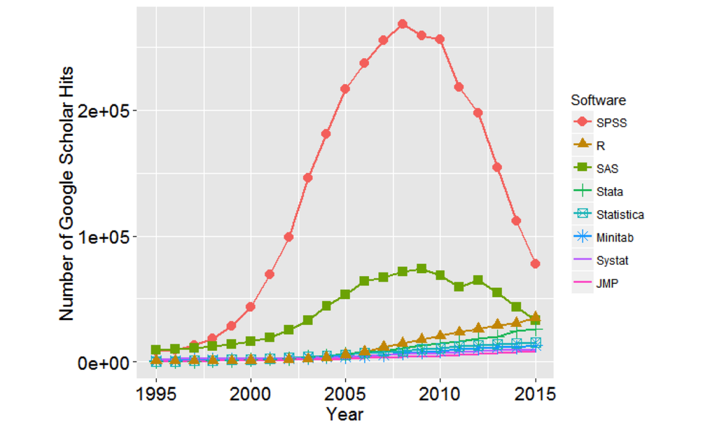

Avots: http://r4stats.com/articles/popularity/

## Popularity of R in ecology

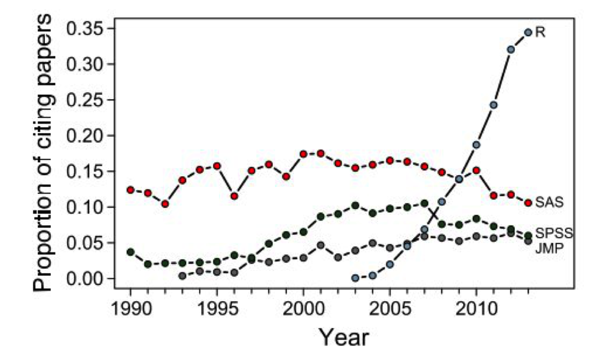

Avots: http://onlinelibrary.wiley.com/doi/10.1002/ecs2.1394/full

Touchon, J.C., McCoy, M.W., 2016. The mismatch between current statistical practice and doctoral training in ecology. Ecosphere, 7 (8).

## Piemērs darbā ar R

Izveidojiet Excel failu, kurā ir divas kolonnas - Garums un Svars, ierakstiet šajās kolonnās izgudrotas 5-10 rindiņas. Saglabājiet šo failu ar nosaukumu Cilveki.xlsx direktorijā My documents (Mani dokumenti)

## Piemērs darbā ar R

```r
if (!require("readxl") )  install.packages("readxl")
library(readxl)
dati <- read_excel("Cilveki.xlsx")
dati
```

```
## # A tibble: 6 × 2
##   Garums Svars
##    <dbl> <dbl>
## 1    175    70
## 2    180    86
## 3    165    61
## 4    163    69
## 5    172    72
## 6    169    68
```

## Programmas

Programmu R var lejupielādēt no mājaslapas https://www.r-project.org, izraugoties CRAN serveri un savai operētājsistēmai atbilstošo versiju.

Programmas RStudio bezmaksas versiju var lejupielādēt:

- jaunākā stabilā versija https://www.rstudio.com/products/rstudio/download/
- jaunākā izstrādes versija https://www.rstudio.com/products/rstudio/download/preview/

## Piemērs

```r
cor.test(dati$Garums,dati$Svars)
```

```
##
##  Pearson's product-moment correlation
##
## data:  dati$Garums and dati$Svars
## t = 2.8434, df = 4, p-value = 0.04671
## alternative hypothesis: true correlation is not equal to 0
## 95 percent confidence interval:
##  0.01894518 0.97937919
## sample estimates:
##       cor
## 0.8179306
```

## Piemērs

```r
summary(lm(Svars~Garums,data=dati))
```

```
##
## Call:
## lm(formula = Svars ~ Garums, data = dati)
##
## Residuals:
##       1       2       3       4       5       6
## -5.6060  5.0795 -3.9768  6.1490 -0.4172 -1.2285
##
## Coefficients:
##              Estimate Std. Error t value Pr(>|t|)
## (Intercept) -110.4040    63.8348  -1.730   0.1588
## Garums         1.0629     0.3738   2.843   0.0467 *
## ---
## Signif. codes:  0 '***' 0.001 '**' 0.01 '*' 0.05 '.' 0.1 ' ' 1
##
## Residual standard error: 5.304 on 4 degrees of freedom
## Multiple R-squared:  0.669,  Adjusted R-squared:  0.5863
## F-statistic: 8.085 on 1 and 4 DF,  p-value: 0.04671
```

## Piemērs

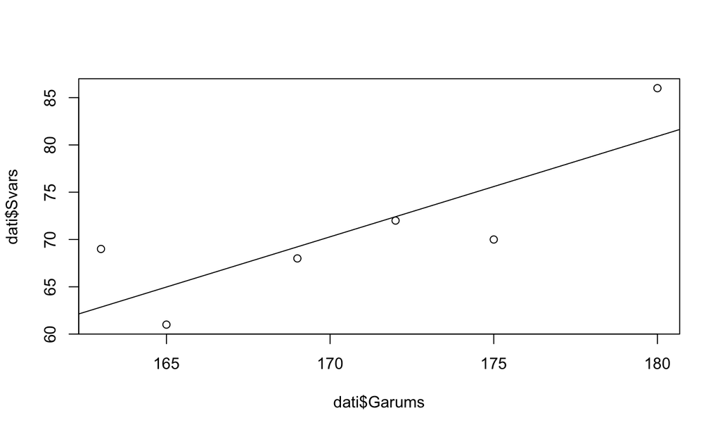

```r
plot(dati$Svars~dati$Garums)
abline(lm(Svars~Garums,data=dati))
```

## Komandu veidošana

- Lai komandu rindai pievienotu komentāru, pirms tā ir jāraksta “#”
- Atstarpes komandās parasti tiek ignorētas, izņēmums ir rakstot “<-”
- Ja komanda ir pārāk gara, tad to var sadalīt vienkārši ar Enter taustiņu
- Iztrūkstošās vērtības programmā R apzīmē ar NA

## Palīdzības iegūšana

```r
help.start()

help(plot)
```

```r
args(cor)
```

```
## function (x, y = NULL, use = "everything", method = c("pearson",
##     "kendall", "spearman"))
## NULL
```

```r
example(plot)
```

Mājaslapā:

http://www.rdocumentation.org/

## R paketes

- Bāzes R programmā ir tikai neliela daļa no iespējām, ko piedāvā R
- Papildus iespējas (funkcijas) pieejamas kā paketes (library), kuras no sākuma jāuzinstalē (ja tas jau nav izdarīts) un tad jāpievieno (tas jādara katrā sesijā)
- Pakešu instalācija notiek ar funkciju `install.packages()`, bet pievienošana darba sesijai ar funkciju `library()`.

```r
install.packages("ggplot2")
library(ggplot2)
```

## R kā kalkulators

R var tikt izmantots kā vienkāršs kalkulators

```r
4+7
```

```
## [1] 11
```

```r
log(8,2)
```

```
## [1] 3
```

```r
exp(2)
```

```
## [1] 7.389056
```

## R citēšana

Ja datu analīzei izmanto R/RStudio, tad darbā obligāti jānorāda atsauce uz programmu R (arī tad, kad izmantojat RStudio, reāli strādājat ar R). Tekstā jānorāda arī R versija.

```r
citation()
```

```
##
##
##   R Core Team (2016). R: A language and environment for
##   statistical computing. R Foundation for Statistical Computing,
##   Vienna, Austria. URL https://www.R-project.org/.
##
## A BibTeX entry for LaTeX users is
##
##   @Manual{,
##     title = {R: A Language and Environment for Statistical Computing},
##     author = {{R Core Team}},
##     organization = {R Foundation for Statistical Computing},
##     address = {Vienna, Austria},
##     year = {2016},
##     url = {https://www.R-project.org/},
##   }
##
## We have invested a lot of time and effort in creating R, please
## cite it when using it for data analysis. See also
## 'citation("pkgname")' for citing R packages.
```

## R citēšana

Ja izmantota kāda papildus pakete, tad jānorāda atsauce arī uz to.

```r
citation("readxl")
```

```
##
##
##   Hadley Wickham (2016). readxl: Read Excel Files. R package
##   version 0.1.1. https://CRAN.R-project.org/package=readxl
##
## A BibTeX entry for LaTeX users is
##
##   @Manual{,
##     title = {readxl: Read Excel Files},
##     author = {Hadley Wickham},
##     year = {2016},
##     note = {R package version 0.1.1},
##     url = {https://CRAN.R-project.org/package=readxl},
##   }
```

## Interaktīva R macīšanās

Izmantojot paketi `swirl` ir iespējams interaktīvi mācīties strādāt programmā R (angļu valodā)

```r
library(swirl)
```

## Datu importēšana

- Bāzes R piedāvā iespējas importēt .txt, .csv un citus ASCI tipas datus
- Izmantojot papildus paketes iespējams importēt ļoti daudzus citus datu formātus - Excel, SPSS, SAS, json, utt

## Datu importēšana

```r
read.table(file=”/../faila.nosaukums.txt”, header=TRUE, sep=”\t”,dec=”.”)
```

Kolonnu atdalītāja `sep=` vērtības var būt: `”\t”` `” , ”` `” ; ”`

Decimāldaļu atdalītājs failā `dec=` varbūt `”.”` vai `”,”`

Pēc noklusējuma visas teksta kolonnas tiek pārvērstas par faktoriem. To var novērst pievienojot argumentu `stringsAsFactors=FALSE`.

Garo saiti uz failu var nerakstīt, ja fails atrodas darba direktorijā (Working directory) (var nomainīt ar `File/Change dir...`)

## Darba direktorija

```r
getwd()
```

```
## [1] "/Users/didzis/Dropbox/DidzaDati/2016/R_kursi_LU/R_kursi_LU/Ievads_R_RStudio"
```

```r
setwd("/Users/didzis/Documents")
```

## Datu importēšana

```r
dati <- read.table(file="niedres.txt",header=T,
                   sep="\t", dec=".")
dati2 <- read.csv2(file="niedres.txt",header=T,
                   sep="\t", dec=".")
```

```r
dati
```

```
##    garums platums
## 1    31.6     2.5
## 2    23.2     2.3
## 3    39.2     2.1
## 4    37.4     5.8
## 5    21.1     2.2
## 6    37.0     4.1
## 7    24.7     3.5
## 8    31.3     4.2
## 9    37.4     2.5
## 10   39.7     2.8
## 11   38.0     4.3
## 12   24.9     1.1
## 13   30.8     1.9
## 14   26.7     0.4
```

[output cut: 36 more lines]

## Datu importēšana - iebūvētie dati

```r
data()
```

## Datu importēšana - iebūvētie dati

```r
data(cars)
head(cars)
```

```
##   speed dist
## 1     4    2
## 2     4   10
## 3     7    4
## 4     7   22
## 5     8   16
## 6     9   10
```

## Datu eksportēšana

Datus, kas izveidoti R kā datu tabulas, visērtāk var eksportēt kā `.txt` vai `.csv` failus.

```r
write.table(x=tas.kas.jaeksporte,
  file="/saite/uz/failu/failanosaukums.txt",
  sep="\t",dec=".")
```

```r
write.table(x=dati, file="eksports.txt",sep="\t",dec=".")
```

Eksportējot pēc noklusējuma tiek eksportēti arī rindiņu nosaukumi. Ja tos nevajag, tad jāpievieno arguments `row.names=FALSE`

## Lietas, kas jāatceras

- Programmā R visi radītie, importētie objekti atrodas operatīvajā atmiņā (ja neizmanto specializētas pieejas)
- Ja neizmanto speciālas paketes, tad R darbībām tiek izmantots tikai viens datora procesors

## Datu veidi

- Skaitliski (numeric), piemēram, 1, 5, 2.6, -123.45
- Rakstu zīmes (character), piemēram, AA, zaļš, mētrājs
- Loģiski (logical) - TRUE un FALSE

## Datu struktūras

- Vektors (vector)
- Matrice (matrix)
- Saraksts (list)
- Datu rāmis/tabula (data frame)
- Datu tabula (data table)
- u.c.

## Datu atlasīšana – datu tabula

```r
dati$garums
```

```
##  [1] 31.6 23.2 39.2 37.4 21.1 37.0 24.7 31.3 37.4 39.7 38.0 24.9 30.8 26.7
## [15] 34.7 33.3 59.0 17.7 24.3 41.4 49.1 46.2 11.9 39.5 45.3 39.6 45.8 31.0
## [29] 39.9 56.4 37.3 41.1 45.3 49.3 24.9 51.7 40.6 43.5 48.9 31.6 53.6 53.5
## [43] 26.9 35.7 46.1 29.1 33.7 43.1 38.8 46.9
```

```r
dati["garums"]
```

```
##    garums
## 1    31.6
## 2    23.2
## 3    39.2
## 4    37.4
## 5    21.1
## 6    37.0
## 7    24.7
## 8    31.3
## 9    37.4
## 10   39.7
## 11   38.0
## 12   24.9
## 13   30.8
## 14   26.7
```

[output cut: 36 more lines]

## Datu atlasīšana – datu tabula

Otrais indekss kvadrātiskajās iekavās nozīmē kolonnas numuru.

```r
dati[,1]
```

```
##  [1] 31.6 23.2 39.2 37.4 21.1 37.0 24.7 31.3 37.4 39.7 38.0 24.9 30.8 26.7
## [15] 34.7 33.3 59.0 17.7 24.3 41.4 49.1 46.2 11.9 39.5 45.3 39.6 45.8 31.0
## [29] 39.9 56.4 37.3 41.1 45.3 49.3 24.9 51.7 40.6 43.5 48.9 31.6 53.6 53.5
## [43] 26.9 35.7 46.1 29.1 33.7 43.1 38.8 46.9
```

```r
dati[,1,drop=FALSE]
```

```
##    garums
## 1    31.6
## 2    23.2
## 3    39.2
## 4    37.4
## 5    21.1
## 6    37.0
## 7    24.7
## 8    31.3
## 9    37.4
## 10   39.7
## 11   38.0
## 12   24.9
## 13   30.8
## 14   26.7
```

[output cut: 36 more lines]

## Datu atlasīšana – datu tabula

Pirmais indekss kvadrātiskajās iekavās nozīmē rindas numuru.

```r
dati[1,]
```

```
##   garums platums
## 1   31.6     2.5
```

```r
dati[c(2,5),]
```

```
##   garums platums
## 2   23.2     2.3
## 5   21.1     2.2
```

```r
dati[1:3,]
```

```
##   garums platums
## 1   31.6     2.5
## 2   23.2     2.3
## 3   39.2     2.1
```

## Darbs ar datiem

```r
garums
```

```r
Error: object 'garums' not found
```

Programmā R datu tabulu kolonnas automātiski netiek uzskatītas par atsevišķiem mainīgiem

## Darba vides sakārtošana

Atmiņā esošo objektu apskatīšana

```r
ls()
```

```
## [1] "cars"  "dati"  "dati2" "img"   "saite" "z"
```

Objekta dzēšana

```r
rm(dati)
```